# Imputing missing data with a mixture

```r
library(proxymix)
```

```r
has_ggplot2 <- requireNamespace("ggplot2", quietly = TRUE)
has_mice <- requireNamespace("mice", quietly = TRUE)
```

## The problem

Datasets often have holes. A measurement was not taken, a questionnaire came back half empty, or a sample was lost. Most analyses need complete rows, so the holes have to be filled first. Filling them with plausible values is called imputation.

Multiple imputation fills each hole several times with random values drawn from a model of the data (Rubin, 1987). The result is several completed datasets. The analysis runs on each of them, and the results are combined, or pooled, into one estimate. The interval around that estimate then includes the uncertainty about the missing values.

Imputed values come from a model, and a wrong model gives wrong values. Many imputation models assume that the data form one cloud shaped like a normal distribution. Real data often fall into groups instead, such as species, sites or types of patient, with few values in between. A model that ignores the groups imputes values in the gap between them. This biases estimates from the completed data.

This vignette imputes data that form two groups and checks the imputed values against the true values that were deleted. It then compares proxymix with two established imputation packages, `mice` and `Amelia`.

## Package capabilities

- `gmm_impute()` fits a Gaussian mixture, a sum of a few normal distributions, to a data matrix with holes. It returns `m` completed datasets. The argument `N` sets the number of components. If `N` is left out, the Bayesian information criterion (BIC) chooses it.
- `gmm_complete()` extracts one completed dataset.
- `proxy_pool()` pools the mean of a column across the completed datasets.
- `proxy_fmi()` reports the fraction of missing information: the share of the information about the mean that the holes removed.
- `as_mids()` converts the completed datasets into the format of the `mice` package. `mice::pool()` can then pool any other estimate, such as a regression slope.

Each missing value is drawn from its conditional distribution, which is the distribution of the missing entry given the observed entries in the same row. When the data are modelled by a Gaussian mixture, this conditional distribution is again a Gaussian mixture (van der Hoek and Elliott, 2024). It has an exact formula, so no simulation is needed. A mixture can have several peaks and a different spread in each group. A single normal distribution cannot.

For a column mean, `proxy_pool()` computes the uncertainty due to the imputed values exactly from the fitted mixture, instead of estimating it from the spread of the completed datasets. That part of the standard error therefore has no added noise from the random draws of the imputed values.

## Addressing the problem

### Data with two groups and known missing values

The data are simulated, so the deleted values are kept and every imputation can be checked against them. There are 600 rows in two groups of about equal size. Within each group, `x1` and `x2` rise together. About half of the `x2` values are then deleted. The chance of deletion rises with the observed `x1` and does not depend on the deleted `x2` itself. This setting is called missing at random.

```r
set.seed(20260620)
n <- 600L
lab <- sample(c(-1, 1), n, replace = TRUE)
x1 <- 2 * lab + rnorm(n, 0, 0.6)
x2 <- 2 * lab + 0.5 * (x1 - 2 * lab) + rnorm(n, 0, 0.6)
truth <- cbind(x1 = x1, x2 = x2)

x_holes <- truth
missing <- runif(n) < plogis(0.6 * x1)
x_holes[missing, "x2"] <- NA
frac_missing <- mean(missing)
```

The values of `x2` cluster near $-2$ and near $+2$, with few values in between. The band $|x_2| < 1$ marks this empty middle. The function `in_gap()` returns the share of values that fall in the band.

```r
in_gap <- function(v) mean(abs(v) < 1)
gap_truth <- in_gap(truth[missing, "x2"])
```

### Impute with a mixture and with a single normal distribution

The first imputation uses a mixture of two normal distributions and makes 20 completed datasets.

```r
imp <- gmm_impute(x_holes, N = 2L, m = 20L, seed = 1L)
imp
```

```
#> <gmm_imputation>: m = 20 completions, K = 2 components, p = 2
#>   mechanism  : missing at random
#>   missing    : x1 0%, x2 53%
```

A completed dataset has no holes left.

```r
done <- gmm_complete(imp, 1L)
anyNA(done)
```

```
#> [1] FALSE
```

With `N = 1L`, the mixture has one component, so the imputation model is a single multivariate normal distribution. Many standard imputation methods make this assumption. It is the point of comparison in this section.

```r
imp1 <- gmm_impute(x_holes, N = 1L, m = 20L, seed = 1L)
done1 <- gmm_complete(imp1, 1L)
```

Share of values in the empty middle, over the 320 deleted entries. The imputation rows use the first completed dataset of each imputation.

| Values | Share with $\lvert x_2 \rvert < 1$ |
| --- | --- |
| deleted values (truth) | 0.069 |
| mixture imputation (N = 2) | 0.084 |
| single-normal imputation (N = 1) | 0.184 |

### Where the imputed values fall

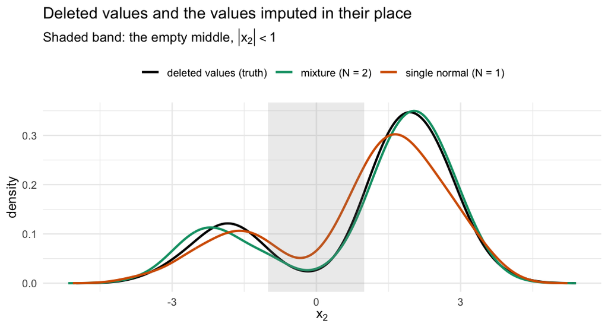

Density of the deleted values of $x_2$ and of the values each imputation put in their place, from the first completed dataset of each. The shaded band is the empty middle, $|x_2| < 1$.

```r
dens_df <- function(v, label) {
  d <- density(v)
  data.frame(x2 = d$x, density = d$y, source = label,
             stringsAsFactors = FALSE)
}
plot_df <- rbind(
  dens_df(truth[missing, "x2"], "deleted values (truth)"),
  dens_df(done[missing, "x2"], "mixture (N = 2)"),
  dens_df(done1[missing, "x2"], "single normal (N = 1)")
)
plot_df$source <- factor(
  plot_df$source,
  levels = c("deleted values (truth)", "mixture (N = 2)",
             "single normal (N = 1)")
)
ggplot2::ggplot(plot_df, ggplot2::aes(x2, density, colour = source)) +
  ggplot2::geom_line(linewidth = 0.9) +
  ggplot2::annotate("rect", xmin = -1, xmax = 1, ymin = -Inf, ymax = Inf,
                    fill = "grey60", alpha = 0.18) +
  ggplot2::scale_colour_manual(
    name = NULL,
    values = c("deleted values (truth)" = "#000000",
               "mixture (N = 2)" = "#009E73",
               "single normal (N = 1)" = "#D55E00")
  ) +
  ggplot2::labs(
    x = expression(x[2]), y = "density",
    title = "Deleted values and the values imputed in their place",
    subtitle = expression("Shaded band: the empty middle, " *
                            group("|", x[2], "|") < 1)
  ) +
  ggplot2::theme_minimal(base_size = 11) +
  ggplot2::theme(legend.position = "top")
```

### Pool the mean of x2

`proxy_pool()` combines the 20 estimates of the mean of `x2` into one estimate with a standard error (SE) and a 95% confidence interval (CI).

```r
pooled <- proxy_pool(imp, "x2")
pooled1 <- proxy_pool(imp1, "x2")
fmi_mix <- proxy_fmi(imp, "x2")
mean_truth <- mean(truth[, "x2"])
err_mix <- abs(pooled$estimate - mean_truth)
err_one <- abs(pooled1$estimate - mean_truth)
```

The mean of $x_2$ from the complete data, from the rows that were not deleted, and pooled over each imputation.

| Data used | Mean of $x_2$ | SE | CI lower | CI upper | Distance from complete data |
| --- | --- | --- | --- | --- | --- |
| complete data, before deletion | 0.0423 |  |  |  | 0.0000 |
| rows not deleted | -1.0809 |  |  |  | 1.1232 |
| mixture imputation (N = 2) | 0.0431 | 0.0913 | -0.1358 | 0.2221 | 0.0008 |
| single-normal imputation (N = 1) | 0.0200 | 0.0937 | -0.1638 | 0.2039 | 0.0223 |

### Pool a regression slope with mice

For estimates other than a column mean, `as_mids()` converts the completed datasets into a `mice` object. The regression of `x2` on `x1` is then fitted in each completed dataset, and `mice::pool()` combines the results by Rubin’s rules. These rules average the estimates and add their spread across the completed datasets to the average variance.

```r
mice_fit <- mice::pool(with(as_mids(imp), lm(x2 ~ x1)))
```

The regression of $x_2$ on $x_1$, fitted in each of the 20 completed datasets of the mixture imputation and pooled by `mice::pool()`.

| term | estimate | std.error | statistic | df | p.value |
| --- | --- | --- | --- | --- | --- |
| (Intercept) | -0.037 | 0.039 | -0.942 | 67.970 | 0.350 |
| x1 | 0.942 | 0.019 | 49.020 | 57.095 | < 0.001 |

### Comparison with mice and Amelia

So far the mixture has been compared only with a single normal distribution, on one dataset. In a simulation, proxymix was compared with two established imputation packages. `mice` (van Buuren and Groothuis-Oudshoorn, 2011) ran with its default method for numeric columns, predictive mean matching, which fills each hole with an observed value from a row whose prediction is similar. `Amelia` (Honaker, King and Blackwell, 2011) draws the missing values from a single multivariate normal distribution fitted to bootstrap resamples of the data. Each package imputed 500 datasets of 500 rows from each of two designs: one normal cloud, and two groups with different correlations. For each simulated dataset, the slope of $x_2$ on $x_1$ was estimated in every completed dataset and pooled by Rubin’s rules. The coverage is the share of simulated datasets whose 95% interval contained the true slope. It should be close to 0.95.

Slope of $x_2$ on $x_1$ over 500 simulated datasets per design. Coverage is the share of 95% intervals that contained the true slope. Error is the root mean squared error of the estimate. With 500 datasets, a coverage near 0.95 has a simulation standard error of about 0.01.

| Data used | Coverage, one cloud | Coverage, two groups | Error, two groups | Interval width, two groups |
| --- | --- | --- | --- | --- |
| complete data, before deletion | 0.948 | 0.964 | 0.030 | 0.127 |
| proxymix | 0.928 | 0.940 | 0.057 | 0.223 |
| mice | 0.766 | 0.828 | 0.055 | 0.150 |
| Amelia | 0.926 | 0.452 | 0.136 | 0.231 |

With two groups, the proxymix intervals contained the true slope in 0.940 of datasets, against 0.828 for `mice` and 0.452 for `Amelia`. `Amelia` fits one normal distribution to both groups, and on average its slope estimates were 0.124 above the true value of 0.854. The `mice` estimates were about as accurate as those of proxymix, but the `mice` intervals were narrower and missed the true slope more often. With one normal cloud, proxymix and `Amelia` did equally well, with coverages of 0.928 and 0.926, while `mice` reached only 0.766.

proxymix is the slowest of the three. Twenty completions of one two-group dataset took 0.74 seconds with proxymix, 0.04 with `mice` and 0.02 with `Amelia` (median of five runs on one computer).

The code below imputes one dataset from the two-group design with all three packages and pools the slope with `mice::pool()` for each. It repeats the simulation code for a single dataset. It needs `mice` and `Amelia`, both on CRAN, and it is not run when this vignette is built.

```r
library(proxymix)
library(mice)
library(Amelia)

# one dataset of 500 rows with two groups
set.seed(1L)
n <- 500L
grp <- runif(n) < 0.5
rho <- ifelse(grp, -0.3, 0.6)
z1 <- rnorm(n)
full <- data.frame(
  x1 = ifelse(grp, 1.5, -1.5) + z1,
  x2 = ifelse(grp, 2, -1.5) + rho * z1 + sqrt(1 - rho^2) * rnorm(n)
)

# delete x2 with a probability that rises with x1
obs <- full
obs$x2[runif(n) < plogis(0.4 + 0.6 * full$x1)] <- NA

# 20 completed datasets from each package
sets <- list(
  proxymix = complete(as_mids(gmm_impute(obs, m = 20L, seed = 1L)), "all"),
  mice = complete(mice(obs, m = 20L, seed = 1L, printFlag = FALSE), "all"),
  Amelia = amelia(obs, m = 20L, p2s = 0L)$imputations
)

# the same regression in every completed dataset, pooled by mice::pool()
lapply(sets, function(s) {
  fits <- lapply(s, function(d) lm(x2 ~ x1, data = d))
  summary(pool(fits), conf.int = TRUE)
})
```

The [extended version of this article](https://max578.github.io/proxymix/articles/extended/missing_data.html) gives the full simulation, its results for the mean as well as the slope, and an example on the Palmer penguins data.

## Interpretation

The table of shares in the empty middle uses the first completed dataset of each imputation. Averaged over all 20 completed datasets, the mixture put 6.0 per cent of its imputed values in the middle, and the single normal distribution put 15.8 per cent there. The single normal distribution put about 2.3 times as much in the middle as the data had.

Both imputations in the figure have two peaks. Each imputed value is drawn given the observed `x1` of its row, and `x1` itself falls into two groups. The imputations differ in the line along which each imputation model draws `x2` from `x1`, and in the spread of the draws around that line. The single-normal model draws from one line for both groups, with a slope of 0.94 and a standard deviation around the line of 0.70. The mixture model draws from one line per group, with slopes of 0.37 and 0.43 and standard deviations of 0.60 and 0.62. In the complete data, the slope within each group is 0.43 and the standard deviation around the line is 0.63. The single-normal imputations are therefore too wide, and their inner edges reach into the middle.

These lines belong to the imputation models, not to the regression that the analyst fits afterwards. The regression of `x2` on `x1` in the table above ignores the groups. Its pooled slope is therefore about 0.94 for both imputations, as it is in the complete data.

The mean of `x2` in the complete data is 0.042. The mean of the rows that were not deleted is -1.081. The two differ because rows with a large `x1`, and therefore a large `x2`, were more likely to be deleted. The pooled means of the mixture and single-normal imputations differ from the complete-data mean by 0.0008 and 0.0223. Both differences are much smaller than the standard errors of about 0.09, so this dataset does not show which imputation gives the better mean. The single normal distribution distorts the shape of the imputed values. The figure shows this distortion. The pooled mean does not.

The fraction of missing information for the mean is 0.097. Although 53 per cent of `x2` is missing, the observed `x1` carries much of the information about `x2`. Only about 10 per cent of the information about the mean is lost.

## Limitations

Everything above assumes numeric data that are missing at random. Under this assumption, the chance that an entry is missing may depend on the observed entries but not on the missing value itself. The assumption cannot be tested from the observed data. Missingness that depends on the missing value, and censoring at a known limit, break it. The `mechanism` argument of `gmm_impute()` handles censoring. It also handles missingness that depends on the missing value, once you assume how strongly the value changes its chance of being missing, as *Missing data that depends on the missing value* shows.

The single-dataset example compares the mixture only with a single normal distribution, on 600 rows in two variables, with the number of components set by hand. It does not show how the method behaves on wide data or with many incomplete columns. The simulation adds predictive mean matching (`mice`) and bootstrapped multivariate normal imputation (`Amelia`), with the number of components chosen by BIC. It does not include other methods that can also represent groups, such as imputation by classification and regression trees. It covers two designs, one pattern of missingness and one sample size. The imputers were not given the group of each row. With the group as a column, `mice` and `Amelia` could model the groups directly.

Estimates other than a column mean are pooled by `mice`, which uses the large-sample rules of Rubin (1987) and inherits their assumptions. The setting with the largest effect on the result is the number of components. With `N = 1`, the imputation model is a single multivariate normal distribution. With far more components than there are real groups, the mixture fits noise into the conditional distribution.

## Further reading

*Missing data that depends on the missing value* covers censoring at a known limit and missingness whose chance depends on the missing value. It shows how to vary the assumed strength of the link between a value and its chance of being missing. The observed data inform that strength only through the assumed shape of the distribution.

*The closed-form operator calculus on a mixture* explains the formulas behind `gmm_conditionalise()` and the other exact operations on a mixture.

*One mixture, many methods* places imputation beside other classical analyses that use a single fitted mixture.

## References

Honaker, J., King, G. and Blackwell, M. (2011). *Amelia II: A program for missing data.* Journal of Statistical Software 45(7), 1–47. https://doi.org/10.18637/jss.v045.i07.

Hoek, J. van der and Elliott, R. J. (2024). *Mixtures of multivariate Gaussians.* Stochastic Analysis and Applications. https://doi.org/10.1080/07362994.2024.2372605.

Rubin, D. B. (1987). *Multiple Imputation for Nonresponse in Surveys.* Wiley.

van Buuren, S. and Groothuis-Oudshoorn, K. (2011). *mice: Multivariate imputation by chained equations in R.* Journal of Statistical Software 45(3), 1–67. https://doi.org/10.18637/jss.v045.i03.

## Reproduce

The data are generated with seed `20260620`, and `gmm_impute()` is given `seed = 1L`. The completed datasets are therefore reproducible, and the seed does not change the random-number state outside the call. The comparison with `mice` and `Amelia` is read from stored results of a simulation run under proxymix 0.17.0, `mice` 3.19.0 and `Amelia` 1.8.3, which took about 17 minutes on one core.